# What predict best about the quality of specified execution of the exercise?

## Step 1.1: organize the data: removing the NAs

First I check on summary(pml_train) and locate all the variabls with huge numbers of NAs, and remove them.

```r
pml_train <- read.csv("pml-training.csv")
pml_test <- read.csv("pml-testing.csv")
summary(pml_train)
vars.for.removed = c(17:36,50:59,75:83,93:94,96:97,99:101,103:112,127,131:132,134:135,137:138,141:150)
pml_trainNARM <- pml_train[,-vars.for.removed]
pml_testNARM <- pml_test[,-vars.for.removed]
```

## Step 1.2: organize the data:

then use describe() to locate variables with very low sd of even equal to zero for the whole set of data

```r
library(psych)
des <- data.frame(describe(pml_trainNARM))
vars.for.removed.sd2=c(2:6,12:16,39:44,48:55,69:76)
pml_trainRM2 <- pml_trainNARM[,-vars.for.removed.sd2]
pml_testRM2 <- pml_testNARM[,-vars.for.removed.sd2]
```

## step 2: split the pml_train

to train and test data sets for further analysis

```r
library(caret)
inTrain <- createDataPartition(y=pml_trainRM2$classe,
                              p=0.7, list=FALSE)
training <- pml_trainRM2[inTrain,]
testing <- pml_trainRM2[-inTrain,]
```

## step 3: fit the model with rpart with all the left variables

```r
library(e1071)
modFit <- train(classe ~ .,method="rpart",data=training)
print(modFit$finalModel)
```

```
## n= 13737
##
## node), split, n, loss, yval, (yprob)
##       * denotes terminal node
##
## 1) root 13737 9831 A (0.28 0.19 0.17 0.16 0.18)
##   2) X< 5580 3906    0 A (1 0 0 0 0) *
##   3) X>=5580 9831 7173 B (0 0.27 0.24 0.23 0.26)
##     6) X< 9377 2658    0 B (0 1 0 0 0) *
##     7) X>=9377 7173 4648 E (0 0 0.33 0.31 0.35) *
```

## step 4: draw the plot of the model we fit

the plot shows “X” being the most important predictor

```r
library(rattle)
fancyRpartPlot(modFit$finalModel)
```

## step 5: predict the test set (the one splited from pml_train)

By using rpart, we get an accuracy rate of 0.6616822

```r
modFitPred <-predict(modFit,newdata=testing)
table(modFitPred,testing$classe)
```

```
##
## modFitPred    A    B    C    D    E
##          A 1674    0    0    0    0
##          B    0 1138    0    0    0
##          C    0    0    0    0    0
##          D    0    0    0    0    0
##          E    0    1 1026  964 1082
```

```r
accucacy= (1674+1138+1082)/nrow(testing)
```

```r
accucacy
```

```
## [1] 0.6617
```

## step 6.1: Fit the model according the the cv trained

```r
library(caret)
set.seed(111)
fitControl = trainControl( method = "cv", number = 10 )
cartGrid = expand.grid( .cp = (1:50)*0.01)
train(classe ~ . , data = training, method = "rpart",
trControl = fitControl, tuneGrid = cartGrid )
```

```
## CART
##
## 13737 samples
##    54 predictors
##     5 classes: 'A', 'B', 'C', 'D', 'E'
##
## No pre-processing
## Resampling: Cross-Validated (10 fold)
##
## Summary of sample sizes: 12364, 12363, 12363, 12363, 12363, 12364, ...
##
## Resampling results across tuning parameters:
##
##   cp    Accuracy  Kappa  Accuracy SD  Kappa SD
##   0.01  1         1      4e-04        4e-04
##   0.02  1         1      4e-04        4e-04
##   0.03  1         1      4e-04        4e-04
##   0.04  1         1      4e-04        4e-04
##   0.05  1         1      4e-04        4e-04
##   0.06  1         1      4e-04        4e-04
##   0.07  1         1      4e-04        4e-04
##   0.08  1         1      4e-04        4e-04
##   0.09  1         1      4e-04        4e-04
##   0.1   1         1      4e-04        4e-04
##   0.1   1         1      4e-04        4e-04
##   0.1   1         1      4e-04        4e-04
##   0.1   1         1      4e-04        4e-04
##   0.1   1         1      4e-04        4e-04
##   0.2   1         1      4e-04        4e-04
##   0.2   1         1      4e-04        4e-04
##   0.2   1         1      4e-04        4e-04
##   0.2   1         1      4e-04        4e-04
##   0.2   1         1      4e-04        4e-04
##   0.2   1         1      4e-04        4e-04
##   0.2   1         1      4e-04        4e-04
##   0.2   1         1      4e-04        4e-04
##   0.2   0.8       0.8    4e-04        5e-04
##   0.2   0.8       0.8    4e-04        5e-04
##   0.2   0.7       0.6    3e-04        4e-04
##   0.3   0.5       0.3    5e-04        4e-04
```

[output cut: 12 more lines]

```
##   0.4   0.3       0      4e-04        0
##   0.4   0.3       0      4e-04        0
##   0.4   0.3       0      4e-04        0
##   0.4   0.3       0      4e-04        0
##   0.4   0.3       0      4e-04        0
##   0.4   0.3       0      4e-04        0
##   0.4   0.3       0      4e-04        0
##   0.5   0.3       0      4e-04        0
##   0.5   0.3       0      4e-04        0
##   0.5   0.3       0      4e-04        0
##   0.5   0.3       0      4e-04        0
##   0.5   0.3       0      4e-04        0
##
## Accuracy was used to select the optimal model using  the largest value.
## The final value used for the model was cp = 0.2.
```

## step 6.3: Using cp = 0.22 to run rpart

From the table get from step 6.1, in order to have error rate equal to zero, I use 0.22 as the largest cp with smallest variance

```r
exerciseTREECV = rpart(classe ~ ., data = training,
control=rpart.control(cp = 0.22))
```

## step 6.3: predict the accuracy using model trained with cv

I get an accuracy of 0.9994902, much higher than the previous raw model, but a little lower than as I had expected.

```r
modFitPred <-predict(exerciseTREECV,newdata=testing,type ="class")
table(modFitPred,testing$classe)
```

```
##
## modFitPred    A    B    C    D    E
##          A 1674    0    0    0    0
##          B    0 1138    0    0    0
##          C    0    1 1026    0    0
##          D    0    0    0  963    0
##          E    0    0    0    1 1082
```

```r
accucacy= (1674+1138+1026+962+1082)/nrow(testing)
```

```r
accucacy
```

```
## [1] 0.9995
```

## step 7.1: fit randomForest model

```r
library(randomForest)
exerciseForest = randomForest(classe ~ ., data = training,imiportance=TRUE,na.action=na.omit,mtry=3)
round(importance(exerciseForest),2)
```

```r
round(importance(exerciseForest),2)
```

```
##                      MeanDecreaseGini
## X                             2153.98
## num_window                     492.38
## roll_belt                      497.30
## pitch_belt                     311.03
## yaw_belt                       366.16
## total_accel_belt               152.51
## gyros_belt_x                    79.45
## gyros_belt_y                    89.14
## gyros_belt_z                   169.25
## accel_belt_x                   103.40
## accel_belt_y                    94.33
## accel_belt_z                   241.72
## magnet_belt_x                  146.65
## magnet_belt_y                  236.61
## magnet_belt_z                  207.94
## roll_arm                       175.43
## pitch_arm                      100.44
## yaw_arm                        125.62
## total_accel_arm                 69.33
## gyros_arm_x                     85.10
## gyros_arm_y                     84.70
## gyros_arm_z                     46.25
## accel_arm_x                    147.08
## accel_arm_y                     95.30
## accel_arm_z                     87.29
## magnet_arm_x                   146.95
## magnet_arm_y                   141.38
## magnet_arm_z                   106.52
## roll_dumbbell                  233.03
## pitch_dumbbell                 134.16
## yaw_dumbbell                   154.30
## total_accel_dumbbell           166.04
## gyros_dumbbell_x                89.77
## gyros_dumbbell_y               145.90
## gyros_dumbbell_z                58.13
## accel_dumbbell_x               165.58
## accel_dumbbell_y               224.22
## accel_dumbbell_z               198.36
## magnet_dumbbell_x              256.95
## magnet_dumbbell_y              304.37
## magnet_dumbbell_z              314.64
## roll_forearm                   214.73
## pitch_forearm                  308.47
## yaw_forearm                    102.09
## total_accel_forearm             65.96
## gyros_forearm_x                 55.58
## gyros_forearm_y                 77.05
## gyros_forearm_z                 56.16
## accel_forearm_x                174.30
## accel_forearm_y                 84.89
## accel_forearm_z                131.12
## magnet_forearm_x               131.76
## magnet_forearm_y               122.57
## magnet_forearm_z               135.79
```

## step 7.2 predict the testing dataset outcome

```r
PredictForest = predict(exerciseForest, newdata = testing)
table(testing$classe, PredictForest)
```

```
##    PredictForest
##        A    B    C    D    E
##   A 1674    0    0    0    0
##   B    0 1139    0    0    0
##   C    0    3 1023    0    0
##   D    0    0   10  954    0
##   E    0    0    0    2 1080
```

```r
accuracy= (1674+1138+1025+963+1082)/nrow(testing)
```

```r
accuracy
```

```
## [1] 0.9995
```

## Fig.1. prp plot of general rpart model

[figure not shown]

## Fig.2. prp plot of the cv model

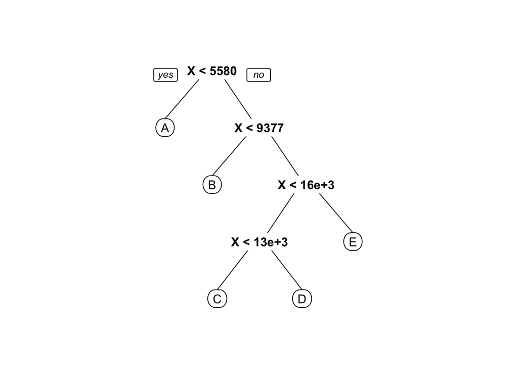

## Fig.3. Classe well predicted by X and roll_belt

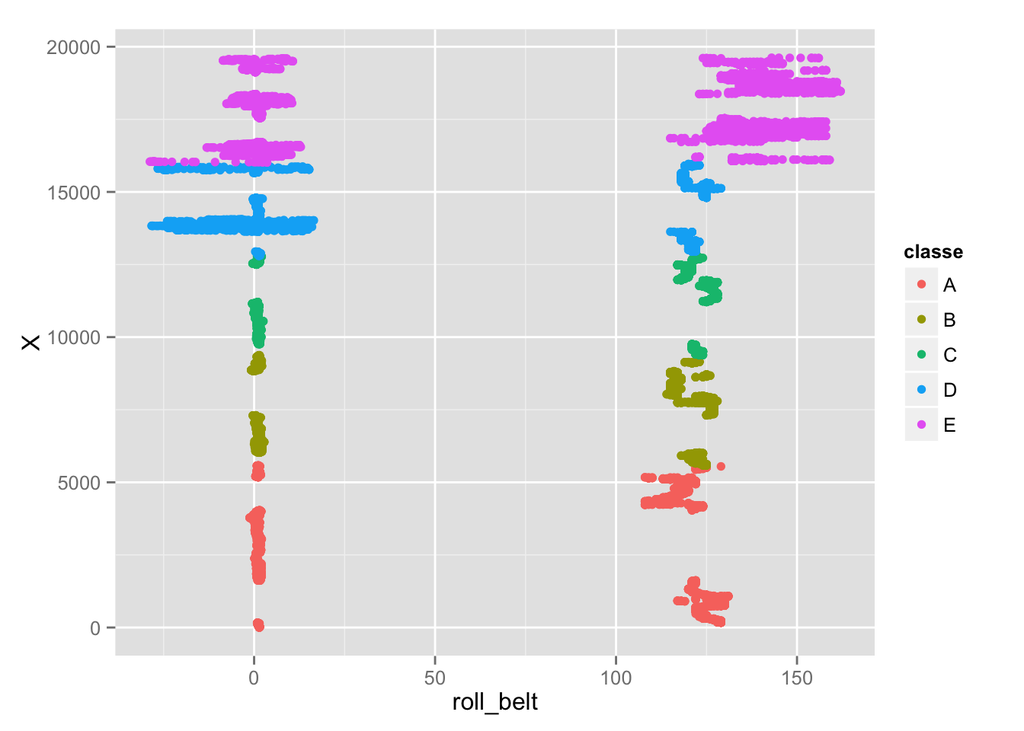

```r
library(ggplot2)
qplot(roll_belt, X, colour=classe,data=training)
```

## Fig.4. Classe well predicted by X and num_window

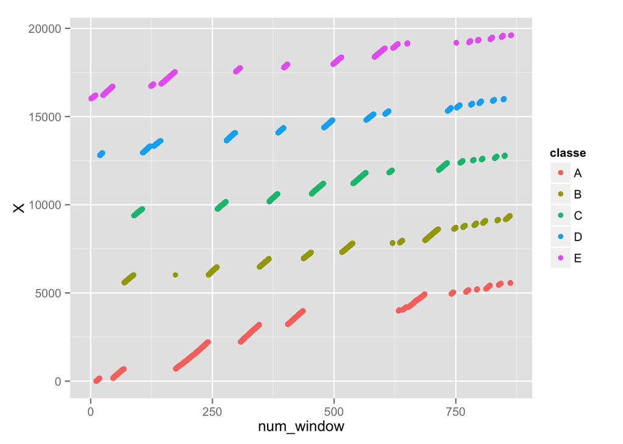

```r
library(ggplot2)
qplot(num_window, X, colour=classe,data=training)
```

## Fig.5. Classe well predicted by X and yaw_belt

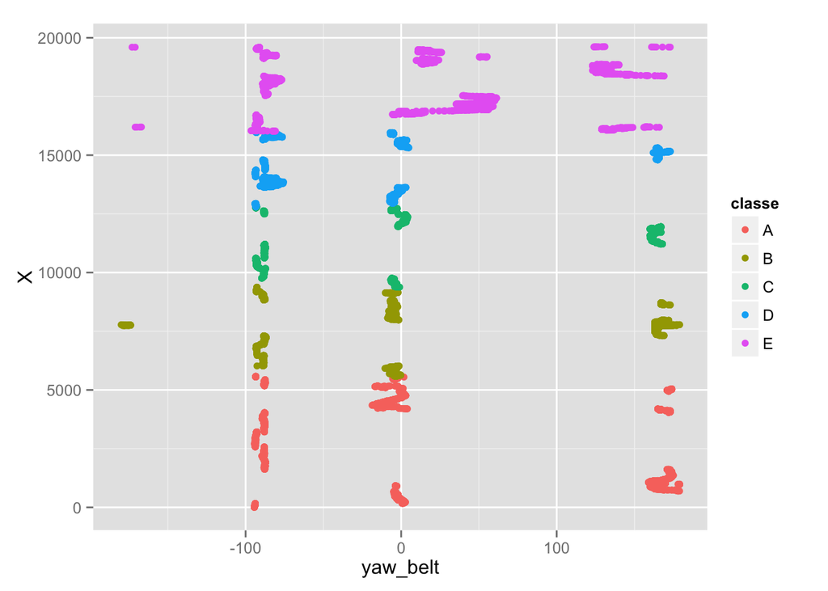

```r
library(ggplot2)
qplot(yaw_belt, X, colour=classe,data=training)
```